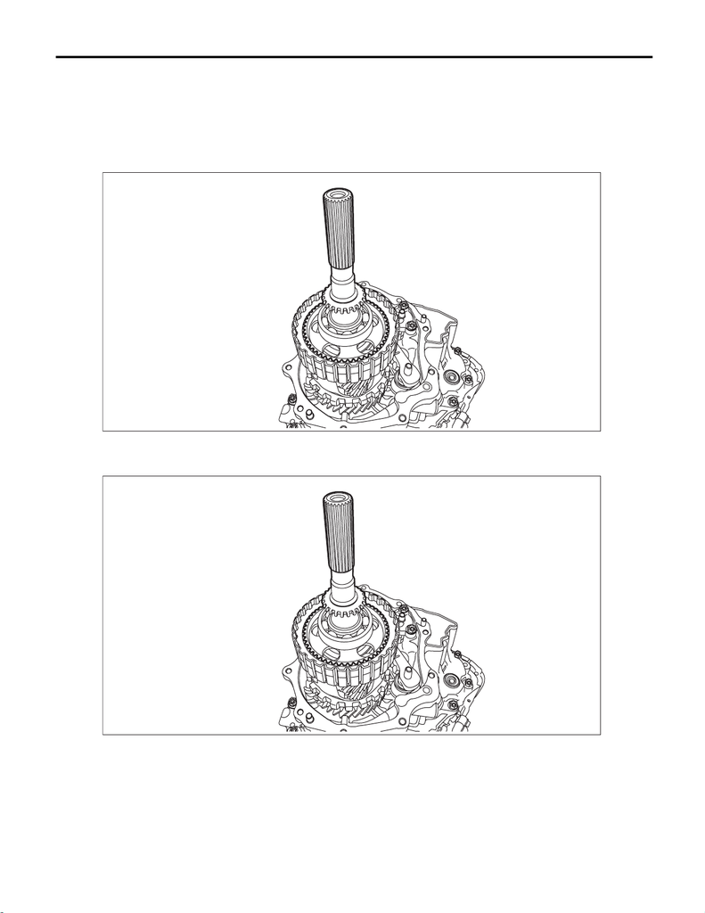

CVT(TR690)-146

Rear Drive Shaft

CONTINUOUSLY VARIABLE TRANSMISSION

29.Rear Drive Shaft

A: REMOVAL

1) Remove the transmission assembly from the vehicle. <Ref. to CVT(TR690)-56, REMOVAL, Automatic

Transmission Assembly.>

2) Remove the extension case. <Ref. to CVT(TR690)-142, REMOVAL, Extension Case.>

3) Remove the rear drive shaft.

B: INSTALLATION

1) Install the rear drive shaft.

2) Select the rear drive shaft shim. <Ref. to CVT(TR690)-149, ADJUSTMENT, Rear Drive Shaft.>

3) Install the selected rear drive shaft shims to the rear drive shaft.

4) Install the extension case. <Ref. to CVT(TR690)-143, INSTALLATION, Extension Case.>

5) Install the transmission assembly to the vehicle. <Ref. to CVT(TR690)-69, INSTALLATION, Automatic

Transmission Assembly.>

AT-07359

AT-07359

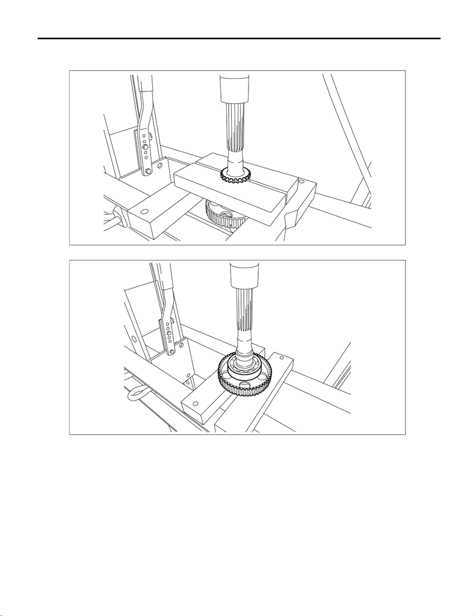

CVT(TR690)-147

Rear Drive Shaft

CONTINUOUSLY VARIABLE TRANSMISSION

C: DISASSEMBLY

1) Using a press, remove the revolution gear.

2) Using a press, remove the front and rear ball bearings and clutch hub.

AT-07385

AT-07386

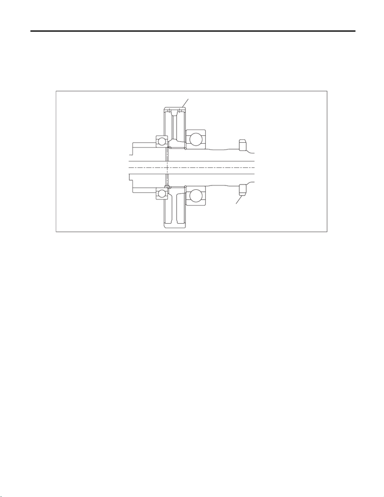

CVT(TR690)-148

Rear Drive Shaft

CONTINUOUSLY VARIABLE TRANSMISSION

D: ASSEMBLY

Assemble in the reverse order of disassembly.

NOTE:

• Use new ball bearings and revolution gear.

• Apply CVTF to press-fitting surface of ball bearing.

• Make sure of the direction of clutch hub.

E: INSPECTION

• Check each part for crack, damage or dust.

• Check the ball bearing for smooth rotation.

• Check the ball bearing for excessive looseness.

• Inspect axial play of the rear drive shaft.

(A) Front side

(B) Clutch hub

(C) Rear side

(D) Revolution gear

AT-07388

(A)

(B)

(C)

(D)

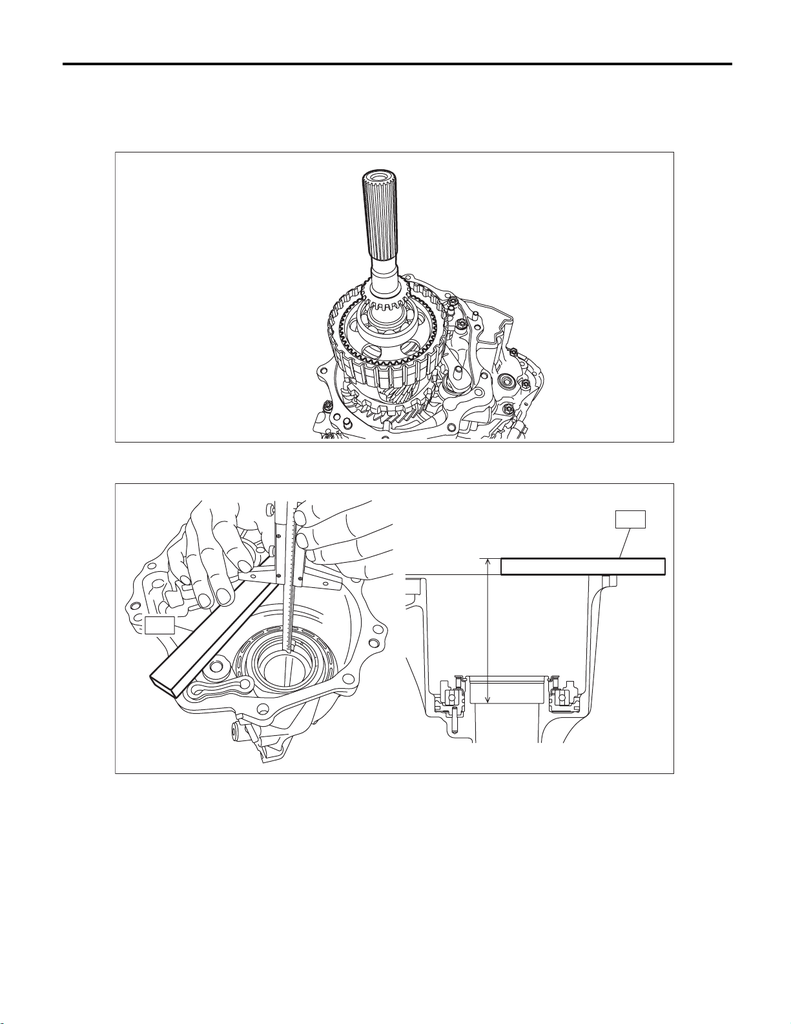

CVT(TR690)-149

Rear Drive Shaft

CONTINUOUSLY VARIABLE TRANSMISSION

F: ADJUSTMENT

NOTE:

When replacing the rear drive shaft or bearing, select the rear drive shaft shim.

1) Install the rear drive shaft.

2) Using the ST, measure the depth “A” from the end surface of ST to the contact surface of ball bearing.

ST 499575400 GAUGE

AT-07359

AT-07393

ST

ST

A

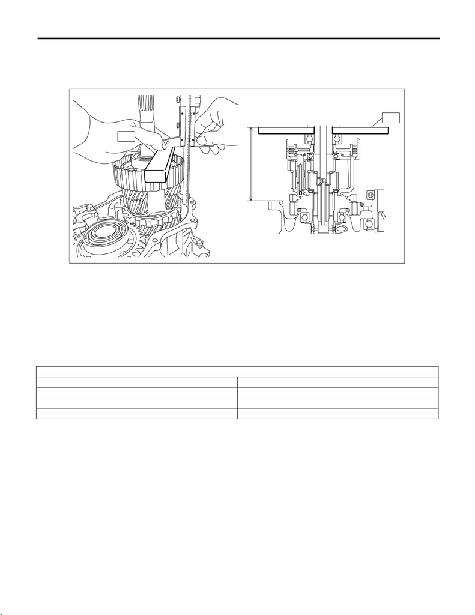

CVT(TR690)-150

Rear Drive Shaft

CONTINUOUSLY VARIABLE TRANSMISSION

3) Using the ST, measure the height “B” from the mating surface of intermediate case to the end surface of ST.

NOTE:

Set the ST so that it does not ride on the bearing inner race.

ST 499575400 GAUGE

4) Obtain the thickness of rear drive shaft shim using the following formula to select none to four rear drive

shaft shims.

T (mm) = A – B + 0.38 – (0.05 — 0.25)

[T (in) = A – B + 0.0149 – (0.002 — 0.01)]

T: Rear drive shaft shim thickness

A: Depth from the ST end surface to the ball bearing contact surface

B: Height from the mating surface of the intermediate case to the ST end face

0.38 mm (0.0149 in): Thickness of gasket

15 mm (0.591 in): Thickness of ST

0.05 — 0.25 mm (0.002 — 0.01 in): Clearance

Rear drive shaft shim

Part No. Thickness mm (in)

33281AA040 0.2 (0.008)

33281AA050 0.5 (0.020)

33281AA060 0.3 (0.012)

AT-07396

ST

ST

B